### Practical Machine Learning Assignment

#### Background

Using devices such as Jawbone Up, Nike FuelBand, and Fitbit it is now possible to collect a large amount of data about personal activity relatively inexpensively. These type of devices are part of the quantified self movement - a group of enthusiasts who take measurements about themselves regularly to improve their health, to find patterns in their behavior, or because they are tech geeks. One thing that people regularly do is quantify how much of a particular activity they do, but they rarely quantify how well they do it.

In this project, the aim is to use data from accelerometers on the belt, forearm, arm, and dumbell of 6 participants to predict the different ways that the participants actually perform the barbell lifts. The participants were asked to perform barbell lifts correctly and incorrectly in 5 different ways.These 5 different ways are represented by the classe variable.

```r
# set working directory and load required packages
setwd("C:/Users/NUS/Desktop/rdata")

suppressWarnings(library(ggplot2))
suppressWarnings(library(randomForest))
library(caret)
library(rpart)
library(rpart.plot)
library(rattle)
library(RColorBrewer)
library(ROCR)
library(gplots)
library(e1071)
library(plyr)
library(splines)
library(parallel)
suppressMessages(library(gbm))
library(survival)
```

```r
training<-read.csv("pml-training.csv",stringsAsFactors=F,na.strings = c("NA","#DIV/0!",""))
testing<-read.csv("pml-testing.csv",stringsAsFactors=F,na.strings = c("NA","#DIV/0!",""))
dim(training)
```

```
## [1] 19622   160
```

```r
dim(testing)
```

```
## [1]  20 160
```

#### Cleaning the Data

Variables with near zero variance, or have too much missing data (i.e. NA values) will be removed from the training dataset.Variables, such as the time stamp and the row numbers, were also removed as they do not provide any useful information in training the predictive model.

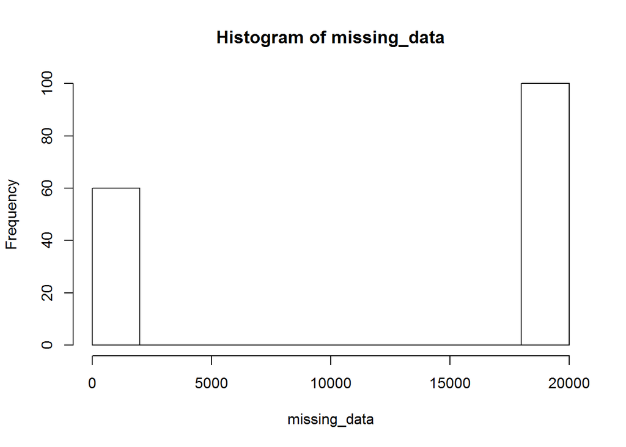

```r
missing_data<- colSums(is.na(training))
hist(missing_data)
```

```r
#Remove variables with nearly zero variance
nzv <- nearZeroVar(training, saveMetrics=TRUE)
training <- training[,nzv$nzv==FALSE]
testing<-testing[,nzv$nzv==FALSE]

#generate a vector that counts the number of NAs in each column
a<-vector()

for(i in 1:length(training)) {
        a[i]<- sum(is.na( training[, i]))
}

# generate a vector that counts the percentage of values in a column that consists of NA values.
b<-a/nrow(training)

# remove any column where the number of NAs exceed 70% of all the values for a variable
#Ensure that the testing dataset has the same number of variables as the training dataset.
training<-training[,b<=0.7]
dim(training)
```

```
## [1] 19622    59
```

```r
testing<-testing[,b<=0.7]
dim(testing)
```

```
## [1] 20 59
```

```r
#remove the first five columns of the remaining dataset as it consist of values that do not contain useful information (for e.g. timestamp, or row numbers)
testing<-testing[,-c(1:5)]
training<-training[,-c(1:5)]
dim(training)
```

```
## [1] 19622    54
```

```r
dim(testing)
```

```
## [1] 20 54
```

#### Generating a Validation Dataset

As seen below, the training dataset is deliberately kept small as running more sophitcated algorithms, such as boosting and random forest models may take some time.

```r
# further divide the training set into a smaller training set and a validation set
# Only a quarter of the training dataset is used to train the machine learning algorithm as unning machine learning algorithms on large datasets may take some time.

set.seed(1000)
partition<-createDataPartition(training$classe,p=0.25,list=FALSE)
subtraining<-training[partition,]
validation<-training[-partition,]
dim(subtraining)
```

```
## [1] 4907   54
```

```r
dim(validation)
```

```
## [1] 14715    54
```

#### Running Machine Learning Algorithms

```r
#Run the decision tree algorithm
rpartFit<-train(classe~.,
                data=training,
                method="rpart",
                trControl=trainControl(method="repeatedcv",
                                       number=10,
                                       repeats=10))

rpartPred<-predict(rpartFit,newdata=validation)
confusionMatrix(validation[,c("classe")],rpartPred)
```

```
## Confusion Matrix and Statistics
##
##           Reference
## Prediction    A    B    C    D    E
##          A 3809   60  307    0    9
##          B 1189  965  693    0    0
##          C 1206   79 1281    0    0
##          D 1093  426  893    0    0
##          E  394  383  728    0 1200
##
## Overall Statistics
##
##                Accuracy : 0.493
##                  95% CI : (0.4849, 0.5011)
##     No Information Rate : 0.5227
##     P-Value [Acc > NIR] : 1
##
##                   Kappa : 0.3372
##  Mcnemar's Test P-Value : NA
##
## Statistics by Class:
##
##                      Class: A Class: B Class: C Class: D Class: E
## Sensitivity            0.4953  0.50444  0.32829       NA  0.99256
## Specificity            0.9465  0.85299  0.88116   0.8361  0.88857
## Pos Pred Value         0.9102  0.33895  0.49922       NA  0.44362
## Neg Pred Value         0.6313  0.92012  0.78426       NA  0.99925
## Prevalence             0.5227  0.13000  0.26517   0.0000  0.08216
## Detection Rate         0.2589  0.06558  0.08705   0.0000  0.08155
## Detection Prevalence   0.2844  0.19348  0.17438   0.1639  0.18383
## Balanced Accuracy      0.7209  0.67872  0.60473       NA  0.94056
```

As seen above, the decision tree algorithm does not perform well, and produces an algorithm that has poor accuracy.For example, the decision tree algorithm does not categorise any observations under classe “D”. As a result,a generalized boosting model is used to fit the data below.

```r
gbmFit<-train(classe~.,
                data=subtraining,
                method="gbm",
                verbose=FALSE)
gbmPred<-predict(gbmFit,newdata=validation)
confusionMatrix(validation[,c("classe")],gbmPred)
```

```
## Confusion Matrix and Statistics
##
##           Reference
## Prediction    A    B    C    D    E
##          A 4155   25    2    3    0
##          B   44 2758   39    6    0
##          C    0   68 2485   13    0
##          D    3    4   34 2350   21
##          E    0   21    5   37 2642
##
## Overall Statistics
##
##                Accuracy : 0.9779
##                  95% CI : (0.9754, 0.9802)
##     No Information Rate : 0.2856
##     P-Value [Acc > NIR] : < 2.2e-16
##
##                   Kappa : 0.9721
##  Mcnemar's Test P-Value : NA
##
## Statistics by Class:
##
##                      Class: A Class: B Class: C Class: D Class: E
## Sensitivity            0.9888   0.9590   0.9688   0.9755   0.9921
## Specificity            0.9971   0.9925   0.9933   0.9950   0.9948
## Pos Pred Value         0.9928   0.9687   0.9684   0.9743   0.9767
## Neg Pred Value         0.9955   0.9901   0.9934   0.9952   0.9983
## Prevalence             0.2856   0.1954   0.1743   0.1637   0.1810
## Detection Rate         0.2824   0.1874   0.1689   0.1597   0.1795
## Detection Prevalence   0.2844   0.1935   0.1744   0.1639   0.1838
## Balanced Accuracy      0.9930   0.9757   0.9811   0.9852   0.9934
```

```r
gbmPred1<-predict(gbmFit,newdata=testing)
print(gbmPred1)
```

```
##  [1] B A B A A E D B A A B C B A E E A B B B
## Levels: A B C D E
```

```r
testing$prediction<-gbmPred1
```

In conclusion, while a decision tree model does not fit the data well, the generalized boosting model works generally well in predicting the dependent variable (i.e. classe).